# Exim CHUNKING Exposure

Rapid7 Labs

2017-11-28

## Introduction

[@todb](https://twitter.com/todb) has a great write-up of the “Exim BDAT Use-After-Free (CVE-2017-16943)” vulnerability over [on the Rapid7 Blog](https://blog.rapid7.com/2017/11/28/cve-2017-16943-exim-bdat-uaf/). Go there. Come back. We’ll wait.

We can quantify the exposure a bit.

Rapid7 has three separate scans for mail servers. These are on ports 25, 465 and 587.

Exim is just one of many mail servers types on the internet and our scans find over 2.3 million unique IPv4s hosting easily identifiable Exim servers.

This vulnerability requires a feature — `CHUNKING` — to be enabled, which we can also look for in the responses to our scans.

Here’s the breakdown of Exim servers — with `CHUNKING` enabled — found by each scan:

| scan | n |
| --- | --- |
| smtps | 147,647 |
| starttls | 139,060 |
| subm | 141,429 |

These scans are designed to catch SSL/TLS certificates for the discovered nodes but they slurp up the plaintext banners as well.

Of those 428,136 nodes, there are 178,125 unique IPv4s, so we’ll work with just the distinct hosts from now on.

## Versions

These are the version summaries (trimmed to the #.## and “Other” for missing or unhelpful strings):

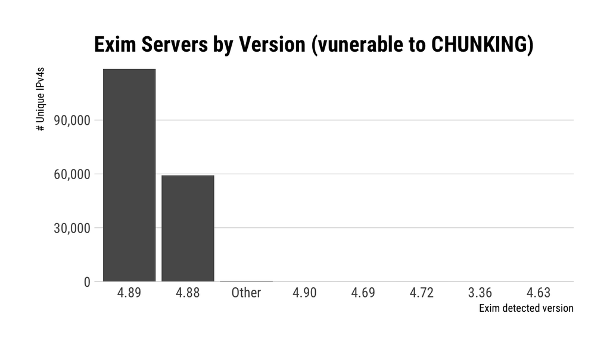

| version | n |
| --- | --- |
| 4.89 | 118,581 |
| 4.88 | 59,168 |
| Other | 364 |
| 4.90 | 5 |
| 4.69 | 3 |
| 4.72 | 2 |
| 3.36 | 1 |
| 4.63 | 1 |

## Country view

They are everywhere, too. Here’s a breakdown by country (you can search/filter):

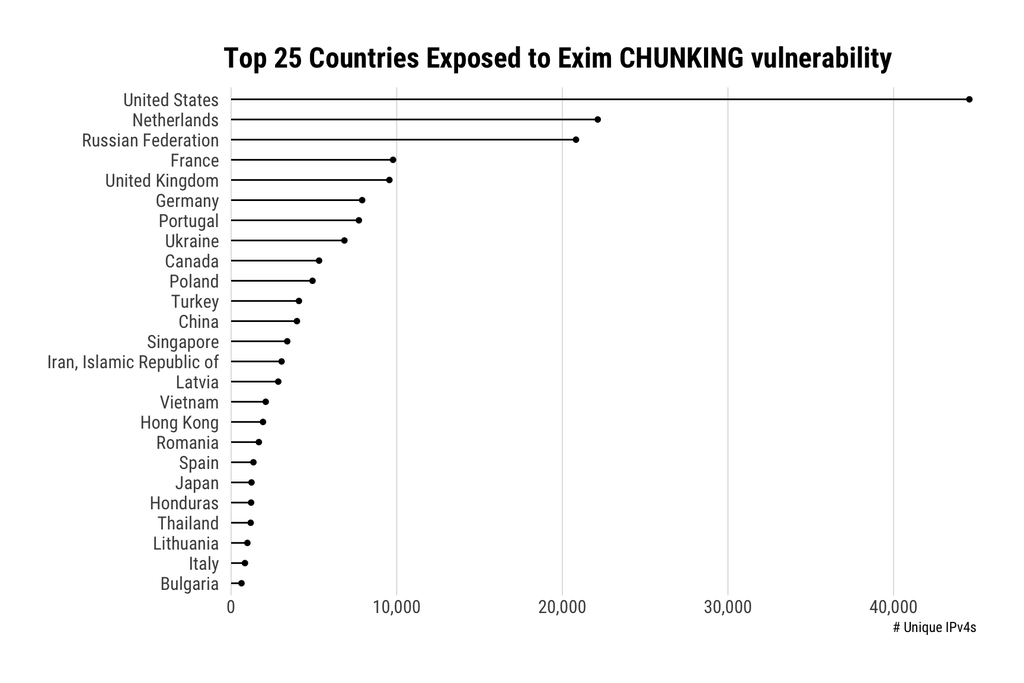

|  | country | n |
| --- | --- | --- |
| 1 | United States | 44577 |
| 2 | Netherlands | 22136 |
| 3 | Russian Federation | 20823 |
| 4 | France | 9776 |
| 5 | United Kingdom | 9556 |
| 6 | Germany | 7911 |
| 7 | Portugal | 7714 |
| 8 | Ukraine | 6839 |
| 9 | Canada | 5309 |
| 10 | Poland | 4914 |

[output cut: 119 more lines]

## Organization view

Here’s a similar breakdown by MaxMind-identified “organization” (which is not ideal but the results are interesting):

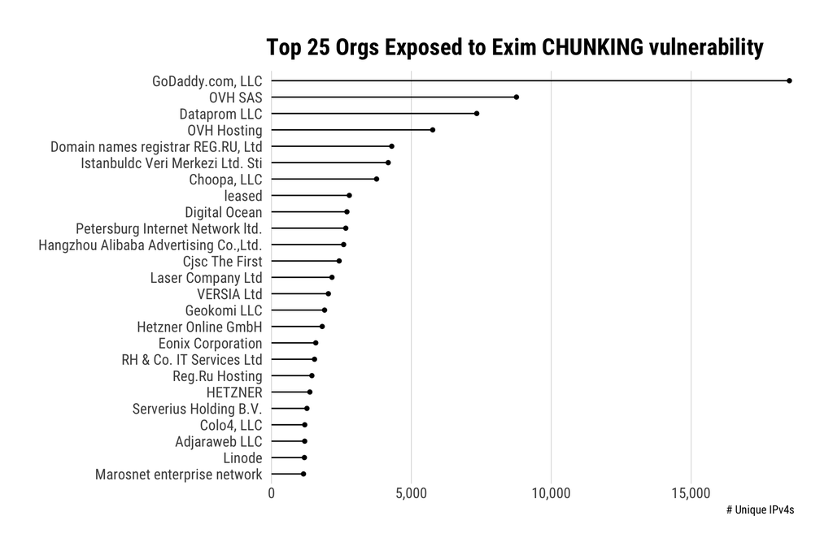

|  | org | n |
| --- | --- | --- |
| 1 | GoDaddy.com, LLC | 18512 |
| 2 | OVH SAS | 8756 |
| 3 | Dataprom LLC | 7337 |
| 4 | OVH Hosting | 5763 |
| 5 | Domain names registrar REG.RU, Ltd | 4299 |
| 6 | Istanbuldc Veri Merkezi Ltd. Sti | 4173 |
| 7 | Choopa, LLC | 3757 |
| 8 | leased | 2783 |
| 9 | Digital Ocean | 2697 |
| 10 | Petersburg Internet Network ltd. | 2656 |

[output cut: 4066 more lines]

## Country and Org view

This adds in counts by country and identified org to make it easier to drill down:

|  | country | org | n |
| --- | --- | --- | --- |
| 1 | United States | GoDaddy.com, LLC | 18511 |
| 2 | France | OVH SAS | 8418 |
| 3 | Portugal | Dataprom LLC | 7337 |
| 4 | Russian Federation | Domain names registrar REG.RU, Ltd | 4299 |
| 5 | Netherlands | Istanbuldc Veri Merkezi Ltd. Sti | 4081 |
| 6 | Canada | OVH Hosting | 3931 |
| 7 | United Kingdom | leased | 2783 |
| 8 | China | Hangzhou Alibaba Advertising Co.,Ltd. | 2580 |
| 9 | Russian Federation | Cjsc The First | 2420 |
| 10 | United States | Digital Ocean | 2209 |

[output cut: 4487 more lines]